# COSC 3337 - Data Science

## Group 10: Alex, Jarrod, Thomas & Jerry

Our dataset is the **Austin Animal Center Shelter Intakes and Outcomes** by Aaron Schlegel on kaggle.com and contains about 80,000 shelter animal intakes and their resulting outcomes (https://www.kaggle.com/aaronschlegel/austin-animal-center-shelter-intakes-and-outcomes?select=aac_intakes_outcomes.csv).

The Austin Animal Center is the largest no-kill animal shelter in the United States that provides care and shelter to over 18,000 animals each year. As part of the AAC's efforts to help and care for animals in need, the organization makes available its accumulated data and statistics as part of the city of Austin's Open Data Initiative (https://data.austintexas.gov/).

This dataset is a merging of two other datasets, aptly named:

**Austin Animal Center Intakes** (https://data.austintexas.gov/Health-and-Community-Services/Austin-Animal-Center-Intakes/wter-evkm) and

**Austin Animal Center Outcomes** (https://data.austintexas.gov/Health-and-Community-Services/Austin-Animal-Center-Outcomes/9t4d-g238)

According to the author of the dataset, who copied from the original Outcomes dataset, the outcome type descriptions are as follows:

**Outcome Types:**

```
Adoption: the animal was adopted to a home

Barn Adoption: the animal was adopted to live in a barn

Offsite Missing: the animal went missing for unknown reasons at an offsite partner location

In-Foster Missing: the animal is missing after being placed in a foster home

In-Kennel Missing: the animal is missing after being transferred to a kennel facility

Possible Theft: Although not confirmed, the animal went missing as a result of theft from the facility

Barn Transfer: The animal was transferred to a facility for adoption into a barn environment

SNR: SNR refers to the city of Austin's Shelter-Neuter-Release program. I believe the outcome is representative of the     animal being released.
```

Because this list provided did not cover all of the outcome types, users on the site asked for further clarification on the terms used in the dataset. The author commented to the users with the following:

```
Disposal: I'm not too sure about this one; my guess is the animal died while in the shelter and its body was disposed       of.

Missing: The animal went missing from the shelter for unknown reasons and has not been located.

Relocation: The animal was transferred to a different location (usually the associated outcome subtype will have more       information as to what facility the animal was moved.

Rto-Adopt: Also not sure on this one, but I believe it represents the animal was returned to its owner through the         shelter's adoption process.
```

(Schlegel): "I apologize, I am not familiar with the Aggressive Behavior, Court/Investigation, Medical and Underage subtypes. Here are the definitions for the remaining subtypes:"

**Outcome Subtypes**

```
In Kennel: The animal was transferred to a kennel

SCRP: Stray Cat Return Program. The cat was likely moved to be placed with that program rather than the shelter, though     I am unable to say for sure.
```

(http://www.maddiesfund.org/austin-animal-services-stray-cat-return-program.htm)

```
SNR: Shelter, neuter, return. A variant of TNR (trap, neuter, release). More information can be found at Maddie's Fund.
```

(http://chewonthis.maddiesfund.org/2013/08/tnr-vs-snr-whats-the-difference/)

**Intake Condition:**

```
Feral: The animal was taken to the shelter as a feral (fearful and possibly aggressive to people)

Euthanasia Request: The animal was brought to the shelter to be euthanatized for unknown reasons.

Public Assist: I am also not sure about this one; my guess is the animal was brought in through an outside rescue           organization.
```

We are only interested in the data from dogs as the dataset also contains several entries of non-adoption animals such as bats, skunks, and raccons.

**1) Data Cleaning**

**Classification Goal: Predicting the outcome_type of a dog entering the shelter**

```
<class 'pandas.core.frame.DataFrame'>
RangeIndex: 79672 entries, 0 to 79671
Data columns (total 41 columns):
 #   Column                      Non-Null Count  Dtype
---  ------                      --------------  -----
 0   age_upon_outcome            79672 non-null  object
 1   animal_id_outcome           79672 non-null  object
 2   date_of_birth               79672 non-null  object
 3   outcome_subtype             36348 non-null  object
 4   outcome_type                79662 non-null  object
 5   sex_upon_outcome            79671 non-null  object
 6   age_upon_outcome_(days)     79672 non-null  int64
 7   age_upon_outcome_(years)    79672 non-null  float64
 8   age_upon_outcome_age_group  79672 non-null  object
 9   outcome_datetime            79672 non-null  object
```

[output cut: 33 more lines]

```
None
```

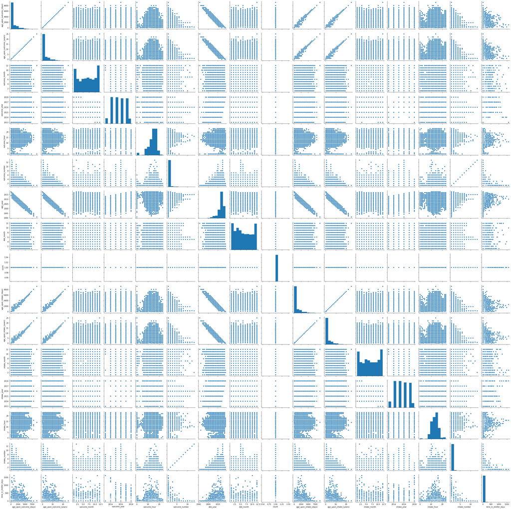

```python
import numpy as np
import pandas as pd
import seaborn as sb

acc1 = pd.read_csv("aac.csv")

display(acc1.info())
sb.pairplot(acc1)
```

**Analysis: we manually selected features based on pairplot and observation of feature definitions, dropping the features that we felt were not pertinent to our analysis. As the majority of features are categorical, the number of features will likely increase considerably after performing one hot encoding, so we are looking to reduce the attributes as much as possible before performing OHE.**

```python
acc2 = acc1.iloc[:,[4,21,22,23,25,26,27,30,33,36,40]]

display( acc2.info())
```

```
<class 'pandas.core.frame.DataFrame'>
RangeIndex: 79672 entries, 0 to 79671
Data columns (total 11 columns):
 #   Column                   Non-Null Count  Dtype
---  ------                   --------------  -----
 0   outcome_type             79662 non-null  object
 1   animal_type              79672 non-null  object
 2   breed                    79672 non-null  object
 3   color                    79672 non-null  object
 4   intake_condition         79672 non-null  object
 5   intake_type              79672 non-null  object
 6   sex_upon_intake          79671 non-null  object
 7   age_upon_intake_(years)  79672 non-null  float64
 8   intake_month             79672 non-null  int64
 9   intake_weekday           79672 non-null  object
 10  time_in_shelter_days     79672 non-null  float64
dtypes: float64(2), int64(1), object(8)
memory usage: 6.7+ MB
```

```
None
```

**Dropping nulls. Likely animals that were currently in the system (no outcome_type)**

```python
acc = pd.DataFrame(acc2.dropna().to_numpy(), columns=['outcome_type','animal_type','breed','color',
                                                      'intake_condition','intake_type',
                                                      'sex_upon_intake','age_upon_intake_years',
                                                      'intake_month','intake_weekday',
                                                      'time_in_shelter_days'])
display(acc.info())
```

```
<class 'pandas.core.frame.DataFrame'>
RangeIndex: 79661 entries, 0 to 79660
Data columns (total 11 columns):
 #   Column                 Non-Null Count  Dtype
---  ------                 --------------  -----
 0   outcome_type           79661 non-null  object
 1   animal_type            79661 non-null  object
 2   breed                  79661 non-null  object
 3   color                  79661 non-null  object
 4   intake_condition       79661 non-null  object
 5   intake_type            79661 non-null  object
 6   sex_upon_intake        79661 non-null  object
 7   age_upon_intake_years  79661 non-null  object
 8   intake_month           79661 non-null  object
 9   intake_weekday         79661 non-null  object
 10  time_in_shelter_days   79661 non-null  object
dtypes: object(11)
memory usage: 6.7+ MB
```

```
None
```

**Getting rid of all other animals | Looking for dogs only and making the rest NaN's to be dropped**

```python
acc.where(acc.iloc[:,[1]] == 'Dog', other=np.NaN, inplace=True, axis=None, level=None, errors='raise', try_cast=False)

display(acc.info())
acc
```

```
<class 'pandas.core.frame.DataFrame'>
RangeIndex: 79661 entries, 0 to 79660
Data columns (total 11 columns):
 #   Column                 Non-Null Count  Dtype
---  ------                 --------------  -----
 0   outcome_type           79661 non-null  object
 1   animal_type            45363 non-null  object
 2   breed                  79661 non-null  object
 3   color                  79661 non-null  object
 4   intake_condition       79661 non-null  object
 5   intake_type            79661 non-null  object
 6   sex_upon_intake        79661 non-null  object
 7   age_upon_intake_years  79661 non-null  object
 8   intake_month           79661 non-null  object
 9   intake_weekday         79661 non-null  object
 10  time_in_shelter_days   79661 non-null  object
dtypes: object(11)
memory usage: 6.7+ MB
```

```
None
```

|  | outcome_type | animal_type | breed | color | intake_condition | intake_type | sex_upon_intake | age_upon_intake_years | intake_month | intake_weekday | time_in_shelter_days |
| --- | --- | --- | --- | --- | --- | --- | --- | --- | --- | --- | --- |
| 0 | Return to Owner | Dog | Spinone Italiano Mix | Yellow/White | Normal | Stray | Neutered Male | 10 | 12 | Thursday | 0.588194 |
| 1 | Return to Owner | Dog | Spinone Italiano Mix | Yellow/White | Normal | Public Assist | Neutered Male | 7 | 12 | Friday | 1.25972 |
| 2 | Return to Owner | Dog | Spinone Italiano Mix | Yellow/White | Normal | Public Assist | Neutered Male | 6 | 3 | Friday | 1.11389 |
| 3 | Transfer | Dog | Dachshund | Tricolor | Normal | Owner Surrender | Neutered Male | 10 | 4 | Wednesday | 4.97014 |
| 4 | Return to Owner | Dog | Shetland Sheepdog | Brown/White | Injured | Public Assist | Neutered Male | 16 | 11 | Saturday | 0.119444 |
| ... | ... | ... | ... | ... | ... | ... | ... | ... | ... | ... | ... |
| 79656 | Transfer | NaN | Domestic Shorthair Mix | Tortie | Normal | Stray | Unknown | 0.0383562 | 3 | Thursday | 0.0770833 |
| 79657 | Euthanasia | NaN | Bat Mix | Brown | Normal | Wildlife | Unknown | 2 | 3 | Thursday | 0.0534722 |
| 79658 | Euthanasia | NaN | Bat Mix | Brown | Normal | Wildlife | Unknown | 1 | 3 | Thursday | 0.0479167 |
| 79659 | Return to Owner | Dog | Labrador Retriever Mix | Black/White | Normal | Stray | Intact Male | 0.410959 | 3 | Thursday | 1.7625 |
| 79660 | Euthanasia | Dog | Boxer Mix | Brown Brindle | Aged | Stray | Spayed Female | 10 | 3 | Thursday | 0.813889 |

79661 rows × 11 columns

**Dropped the animal_types other than dog and removed the column and recovering as many numeric dtypes as possible, then viewing data**

```python
accc = pd.DataFrame(acc.dropna().to_numpy(), columns=['outcome_type','animal_type','breed','color',
                                                      'intake_condition','intake_type',
                                                      'sex_upon_intake','age_upon_intake_years',
                                                      'intake_month','intake_weekday',
                                                      'time_in_shelter_days'])

accc.pop('animal_type')

daccc = accc.convert_dtypes()
accc.info()
daccc.info()
daccc
```

```
<class 'pandas.core.frame.DataFrame'>
RangeIndex: 45363 entries, 0 to 45362
Data columns (total 10 columns):
 #   Column                 Non-Null Count  Dtype
---  ------                 --------------  -----
 0   outcome_type           45363 non-null  object
 1   breed                  45363 non-null  object
 2   color                  45363 non-null  object
 3   intake_condition       45363 non-null  object
 4   intake_type            45363 non-null  object
 5   sex_upon_intake        45363 non-null  object
 6   age_upon_intake_years  45363 non-null  object
 7   intake_month           45363 non-null  object
 8   intake_weekday         45363 non-null  object
 9   time_in_shelter_days   45363 non-null  object
dtypes: object(10)
memory usage: 3.5+ MB
<class 'pandas.core.frame.DataFrame'>
RangeIndex: 45363 entries, 0 to 45362
Data columns (total 10 columns):
 #   Column                 Non-Null Count  Dtype
---  ------                 --------------  -----
 0   outcome_type           45363 non-null  string
 1   breed                  45363 non-null  string
 2   color                  45363 non-null  string
 3   intake_condition       45363 non-null  string
 4   intake_type            45363 non-null  string
 5   sex_upon_intake        45363 non-null  string
 6   age_upon_intake_years  45363 non-null  float64
 7   intake_month           45363 non-null  Int64
 8   intake_weekday         45363 non-null  string
 9   time_in_shelter_days   45363 non-null  float64
dtypes: Int64(1), float64(2), string(7)
memory usage: 3.5 MB
```

|  | outcome_type | breed | color | intake_condition | intake_type | sex_upon_intake | age_upon_intake_years | intake_month | intake_weekday | time_in_shelter_days |
| --- | --- | --- | --- | --- | --- | --- | --- | --- | --- | --- |
| 0 | Return to Owner | Spinone Italiano Mix | Yellow/White | Normal | Stray | Neutered Male | 10.000000 | 12 | Thursday | 0.588194 |
| 1 | Return to Owner | Spinone Italiano Mix | Yellow/White | Normal | Public Assist | Neutered Male | 7.000000 | 12 | Friday | 1.259722 |
| 2 | Return to Owner | Spinone Italiano Mix | Yellow/White | Normal | Public Assist | Neutered Male | 6.000000 | 3 | Friday | 1.113889 |
| 3 | Transfer | Dachshund | Tricolor | Normal | Owner Surrender | Neutered Male | 10.000000 | 4 | Wednesday | 4.970139 |
| 4 | Return to Owner | Shetland Sheepdog | Brown/White | Injured | Public Assist | Neutered Male | 16.000000 | 11 | Saturday | 0.119444 |
| ... | ... | ... | ... | ... | ... | ... | ... | ... | ... | ... |
| 45358 | Transfer | Miniature Poodle/Maltese | White | Normal | Stray | Intact Female | 0.164384 | 3 | Thursday | 4.075000 |
| 45359 | Return to Owner | Beagle/Australian Cattle Dog | White/Red | Normal | Public Assist | Neutered Male | 0.657534 | 3 | Thursday | 5.106944 |
| 45360 | Return to Owner | Border Collie Mix | White/Tricolor | Normal | Stray | Neutered Male | 1.000000 | 3 | Thursday | 0.104861 |
| 45361 | Return to Owner | Labrador Retriever Mix | Black/White | Normal | Stray | Intact Male | 0.410959 | 3 | Thursday | 1.762500 |
| 45362 | Euthanasia | Boxer Mix | Brown Brindle | Aged | Stray | Spayed Female | 10.000000 | 3 | Thursday | 0.813889 |

45363 rows × 10 columns

**Interesting stat details (unique) (top/freq) (max/min/mean) and potential outliers**

```python
daccc.describe(include='all')
```

|  | outcome_type | breed | color | intake_condition | intake_type | sex_upon_intake | age_upon_intake_years | intake_month | intake_weekday | time_in_shelter_days |
| --- | --- | --- | --- | --- | --- | --- | --- | --- | --- | --- |
| count | 45363 | 45363 | 45363 | 45363 | 45363 | 45363 | 45363.000000 | 45363.000000 | 45363 | 45363.000000 |
| unique | 8 | 1919 | 337 | 8 | 4 | 5 | NaN | NaN | 7 | NaN |
| top | Adoption | Pit Bull Mix | Black/White | Normal | Stray | Intact Male | NaN | NaN | Wednesday | NaN |
| freq | 20581 | 6255 | 5201 | 41557 | 32157 | 14831 | NaN | NaN | 6864 | NaN |
| mean | NaN | NaN | NaN | NaN | NaN | NaN | 2.680131 | 6.485704 | NaN | 15.897884 |
| std | NaN | NaN | NaN | NaN | NaN | NaN | 3.033855 | 3.557602 | NaN | 44.431891 |
| min | NaN | NaN | NaN | NaN | NaN | NaN | 0.000000 | 1.000000 | NaN | 0.000000 |
| 25% | NaN | NaN | NaN | NaN | NaN | NaN | 0.739726 | 3.000000 | NaN | 2.093403 |
| 50% | NaN | NaN | NaN | NaN | NaN | NaN | 2.000000 | 6.000000 | NaN | 5.064583 |
| 75% | NaN | NaN | NaN | NaN | NaN | NaN | 4.000000 | 10.000000 | NaN | 11.117014 |
| max | NaN | NaN | NaN | NaN | NaN | NaN | 20.000000 | 12.000000 | NaN | 1606.194444 |

**Analysis: In order to further reduce the categorical values in preparation for one hot encoding, we elected to use the first listing when it came to mixed color or breed, as this would reduce features later on.**

```python
daccc['breed'] = daccc['breed'].str.split(' Mix').str[0]
daccc['breed'] = daccc['breed'].str.split('/').str[0]
daccc['color'] = daccc['color'].str.split('/').str[0]
daccc
```

|  | outcome_type | breed | color | intake_condition | intake_type | sex_upon_intake | age_upon_intake_years | intake_month | intake_weekday | time_in_shelter_days |
| --- | --- | --- | --- | --- | --- | --- | --- | --- | --- | --- |
| 0 | Return to Owner | Spinone Italiano | Yellow | Normal | Stray | Neutered Male | 10.000000 | 12 | Thursday | 0.588194 |
| 1 | Return to Owner | Spinone Italiano | Yellow | Normal | Public Assist | Neutered Male | 7.000000 | 12 | Friday | 1.259722 |
| 2 | Return to Owner | Spinone Italiano | Yellow | Normal | Public Assist | Neutered Male | 6.000000 | 3 | Friday | 1.113889 |
| 3 | Transfer | Dachshund | Tricolor | Normal | Owner Surrender | Neutered Male | 10.000000 | 4 | Wednesday | 4.970139 |
| 4 | Return to Owner | Shetland Sheepdog | Brown | Injured | Public Assist | Neutered Male | 16.000000 | 11 | Saturday | 0.119444 |
| ... | ... | ... | ... | ... | ... | ... | ... | ... | ... | ... |
| 45358 | Transfer | Miniature Poodle | White | Normal | Stray | Intact Female | 0.164384 | 3 | Thursday | 4.075000 |
| 45359 | Return to Owner | Beagle | White | Normal | Public Assist | Neutered Male | 0.657534 | 3 | Thursday | 5.106944 |
| 45360 | Return to Owner | Border Collie | White | Normal | Stray | Neutered Male | 1.000000 | 3 | Thursday | 0.104861 |
| 45361 | Return to Owner | Labrador Retriever | Black | Normal | Stray | Intact Male | 0.410959 | 3 | Thursday | 1.762500 |
| 45362 | Euthanasia | Boxer | Brown Brindle | Aged | Stray | Spayed Female | 10.000000 | 3 | Thursday | 0.813889 |

45363 rows × 10 columns

**Looking for potential reductions ahead of one-hot-encoding**

```python
daccc.nunique()
```

```
outcome_type                 8
breed                      197
color                       36
intake_condition             8
intake_type                  4
sex_upon_intake              5
age_upon_intake_years       43
intake_month                12
intake_weekday               7
time_in_shelter_days     19962
dtype: int64
```

**Reducing time_in_shelter_days to reflect whole days**

```python
for i in daccc.index:
    if daccc.iloc[i, 9] <= 1:
        daccc.iloc[i, 9] = 1
    else:
        daccc.iloc[i, 9] = round(daccc.iloc[i, 9])

daccc.nunique()
```

```
outcome_type               8
breed                    197
color                     36
intake_condition           8
intake_type                4
sex_upon_intake            5
age_upon_intake_years     43
intake_month              12
intake_weekday             7
time_in_shelter_days     424
dtype: int64
```

**Encoding our target "outcome_type" to become numeric (int32)**

```python
from sklearn import preprocessing

le = preprocessing.LabelEncoder()
daccc.iloc[:,0] = le.fit_transform(daccc.iloc[:,0])

# daccc.iloc[0:10,0]
daccc.info()
```

```
<class 'pandas.core.frame.DataFrame'>
RangeIndex: 45363 entries, 0 to 45362
Data columns (total 10 columns):
 #   Column                 Non-Null Count  Dtype
---  ------                 --------------  -----
 0   outcome_type           45363 non-null  int32
 1   breed                  45363 non-null  object
 2   color                  45363 non-null  object
 3   intake_condition       45363 non-null  string
 4   intake_type            45363 non-null  string
 5   sex_upon_intake        45363 non-null  string
 6   age_upon_intake_years  45363 non-null  float64
 7   intake_month           45363 non-null  Int64
 8   intake_weekday         45363 non-null  string
 9   time_in_shelter_days   45363 non-null  float64
dtypes: Int64(1), float64(2), int32(1), object(2), string(4)
memory usage: 3.3+ MB
```

**Changing non-numeric dtypes to "object" to match one-hot-encoding requirements**

```python
daccc['intake_condition'] = daccc['intake_condition'].astype('object')
daccc['intake_type'] = daccc['intake_type'].astype('object')
daccc['sex_upon_intake'] = daccc['sex_upon_intake'].astype('object')
daccc['intake_weekday'] = daccc['intake_weekday'].astype('object')

daccc.info()
```

```
<class 'pandas.core.frame.DataFrame'>
RangeIndex: 45363 entries, 0 to 45362
Data columns (total 10 columns):
 #   Column                 Non-Null Count  Dtype
---  ------                 --------------  -----
 0   outcome_type           45363 non-null  int32
 1   breed                  45363 non-null  object
 2   color                  45363 non-null  object
 3   intake_condition       45363 non-null  object
 4   intake_type            45363 non-null  object
 5   sex_upon_intake        45363 non-null  object
 6   age_upon_intake_years  45363 non-null  float64
 7   intake_month           45363 non-null  Int64
 8   intake_weekday         45363 non-null  object
 9   time_in_shelter_days   45363 non-null  float64
dtypes: Int64(1), float64(2), int32(1), object(6)
memory usage: 3.3+ MB
```

**We preferred using pandas.get_dummies instead of one-hot-encoding**

```python
dacc = pd.get_dummies(daccc)
dacc.info()
dacc.head()
```

```
<class 'pandas.core.frame.DataFrame'>
RangeIndex: 45363 entries, 0 to 45362
Columns: 261 entries, outcome_type to intake_weekday_Wednesday
dtypes: Int64(1), float64(2), int32(1), uint8(257)
memory usage: 12.4 MB
```

|  | outcome_type | age_upon_intake_years | intake_month | time_in_shelter_days | breed_Affenpinscher | breed_Afghan Hound | breed_Airedale Terrier | breed_Akbash | breed_Akita | breed_Alaskan Husky | ... | sex_upon_intake_Neutered Male | sex_upon_intake_Spayed Female | sex_upon_intake_Unknown | intake_weekday_Friday | intake_weekday_Monday | intake_weekday_Saturday | intake_weekday_Sunday | intake_weekday_Thursday | intake_weekday_Tuesday | intake_weekday_Wednesday |
| --- | --- | --- | --- | --- | --- | --- | --- | --- | --- | --- | --- | --- | --- | --- | --- | --- | --- | --- | --- | --- | --- |
| 0 | 5 | 10.0 | 12 | 1.0 | 0 | 0 | 0 | 0 | 0 | 0 | ... | 1 | 0 | 0 | 0 | 0 | 0 | 0 | 1 | 0 | 0 |
| 1 | 5 | 7.0 | 12 | 1.0 | 0 | 0 | 0 | 0 | 0 | 0 | ... | 1 | 0 | 0 | 1 | 0 | 0 | 0 | 0 | 0 | 0 |
| 2 | 5 | 6.0 | 3 | 1.0 | 0 | 0 | 0 | 0 | 0 | 0 | ... | 1 | 0 | 0 | 1 | 0 | 0 | 0 | 0 | 0 | 0 |
| 3 | 7 | 10.0 | 4 | 5.0 | 0 | 0 | 0 | 0 | 0 | 0 | ... | 1 | 0 | 0 | 0 | 0 | 0 | 0 | 0 | 0 | 1 |
| 4 | 5 | 16.0 | 11 | 1.0 | 0 | 0 | 0 | 0 | 0 | 0 | ... | 1 | 0 | 0 | 0 | 0 | 1 | 0 | 0 | 0 | 0 |

5 rows × 261 columns

**Analysis: we performed one hot encoding as the majority of our features are categorical. However, this led to a considerable increase in features, and thus we plan on tackling this later on through the use of PCA.**

**Scaling the data and splitting it up for prediction training**

```python
from sklearn.model_selection import train_test_split
from sklearn.preprocessing import RobustScaler

rs = RobustScaler()

X = dacc.iloc[:, 1:261]
y = dacc.iloc[:, [0]]

X_train , X_test , y_train, y_test = train_test_split(X, y, test_size=0.30, random_state=123)#, stratify=y)

X_train = rs.fit_transform(X_train)
X_test = rs.transform(X_test)
```

**Applying PCA because "one-hot-encoding" greatly expanded the feature space**

```python
from sklearn.decomposition import PCA

pca = PCA(n_components=3)
X_train = pca.fit_transform(X_train)
X_test = pca.transform(X_test)

print(pca.explained_variance_ratio_)
print(pca.singular_values_)
```

```
[0.82360899 0.03152056 0.01237997]
[871.57731712 170.50704352 106.85755136]
```

```python
from sklearn.linear_model import LogisticRegression
from sklearn.ensemble import RandomForestClassifier
from sklearn.tree import DecisionTreeClassifier
from sklearn.linear_model import RidgeClassifier
from sklearn.ensemble import BaggingClassifier
from sklearn.naive_bayes import GaussianNB
from sklearn import model_selection

from sklearn.model_selection import cross_val_score
# from sklearn.metrics import confusion_matrix
# from sklearn.metrics import accuracy_score

rf = RandomForestClassifier(max_depth=4, random_state=0)
dt = DecisionTreeClassifier(random_state=0, max_depth=5)
lgr = LogisticRegression(max_iter=1000)
rdg = RidgeClassifier()
bg = BaggingClassifier()
nb = GaussianNB()

# seed = 7
# kfold = model_selection.KFold(n_splits=10, random_state=seed, shuffle=True)
# scores = model_selection.cross_val_score(lgr, X_train, y_train.values.ravel(), cv=kfold) #cv=10)
# print('LGR Scores: ', scores, "\n")
# model_selection.cross_val_score

scores = cross_val_score(dt, X_train, y_train.values.ravel(), cv=10) # cv=kfold
print('DT Scores: ', scores, "\n")
scores = cross_val_score(rf, X_train, y_train.values.ravel(), cv=10)
print('RF Scores: ', scores, "\n")
scores = cross_val_score(bg, X_train, y_train.values.ravel(), cv=10)
print('BG Scores: ', scores, "\n")
scores = cross_val_score(lgr, X_train, y_train.values.ravel(), cv=10)
print('LGR Scores: ', scores, "\n")
scores = cross_val_score(rdg, X_train, y_train.values.ravel(), cv=10)
print('RDG Scores: ', scores, "\n")
scores = cross_val_score(nb, X_train, y_train.values.ravel(), cv=10)
print('NB Scores: ', scores, "\n")
```

```
DT Scores:  [0.70308564 0.69049118 0.70308564 0.69458438 0.7007874  0.70267717
 0.6976378  0.69700787 0.68377953 0.7007874 ]

RF Scores:  [0.69993703 0.68734257 0.69269521 0.68356423 0.69165354 0.69417323
 0.6903937  0.69133858 0.6815748  0.68850394]

BG Scores:  [0.6813602  0.66813602 0.68167506 0.67758186 0.67370079 0.68535433
 0.67023622 0.68062992 0.67149606 0.68      ]

LGR Scores:  [0.55761965 0.55698992 0.54439547 0.55100756 0.5496063  0.55401575
 0.54393701 0.55370079 0.55433071 0.56094488]

RDG Scores:  [0.51605793 0.50881612 0.51416877 0.51889169 0.50582677 0.52
 0.51023622 0.51559055 0.50992126 0.52503937]

NB Scores:  [0.51889169 0.51353904 0.51700252 0.51731738 0.52251969 0.50677165
 0.50677165 0.51716535 0.49795276 0.52755906]
```

**Analysis: A comparison of classification models with Decision Tree outperforming the rest. Consistent values in the crossval scores shows no fitting issues.**